# Importing necessary libraries

```python
import pandas as pd
import numpy as np
import matplotlib.pyplot as plt
import seaborn as sns
from imblearn.over_sampling import SMOTE
from sklearn.metrics import accuracy_score, confusion_matrix, classification_report
from sklearn.preprocessing import StandardScaler, LabelEncoder
from sklearn.impute import SimpleImputer
from sklearn.ensemble import RandomForestClassifier, GradientBoostingClassifier
from sklearn.model_selection import cross_val_score, train_test_split, GridSearchCV
from sklearn.tree import DecisionTreeClassifier
```

## Loading the data

In today's highly competitive banking industry, retaining existing clients is very important for long-term success of the bank. Customer churn, which refers to the losing of clients over a given period. When it happens the bank not only loses revenue but also is pushed to increase additional costs for new customers. Predicting customers leaving the bank can help a bank identify which customers are most likely to leave so the bank can approach them to try to change it so there are less customers that will leave. It can be done by providing some personal services, giving some deals for them, etc. The business problem that I will be trying to solve in this project is the prediction of customer churn in a bank. My goal is to be able to predict what kind of customers are most likely to leave the bank in the future. To solve this problem, I will use a machine learning approach. By using a dataset from Kaggle:(https://www.kaggle.com/datasets/gauravtopre/bank-customer-churn-dataset). To approach this problem I created a small plan to first visualize the data to make some data exploration, do data preprocessing to prepare data for machine learning and assess the model.

```python
file_path = 'churn.csv'

df = pd.read_csv(file_path)

print(df.head())
```

```
   RowNumber  CustomerId   Surname  CreditScore Geography  Gender  Age  \
0          1    15634602  Hargrave          619    France  Female   42
1          2    15647311      Hill          608     Spain  Female   41
2          3    15619304      Onio          502    France  Female   42
3          4    15701354      Boni          699    France  Female   39
4          5    15737888  Mitchell          850     Spain  Female   43

   Tenure    Balance  NumOfProducts  HasCrCard  IsActiveMember  \
0       2       0.00              1          1               1
1       1   83807.86              1          0               1
2       8  159660.80              3          1               0
3       1       0.00              2          0               0
4       2  125510.82              1          1               1

   EstimatedSalary  Exited
0        101348.88       1
1        112542.58       0
2        113931.57       1
3         93826.63       0
4         79084.10       0
```

## Data Exploration

First step in this pipeline is Data exploration. So I started by getting basic information about the data set. To do it I used the methods df.() which provides an overview of the pandas data frame. Then next lines are printing missing and duplicate rows by calculating sum and displaying them. Next line creates a new DataFrame (numeric_df) that only includes columns that have numeric data types which will be useful in statistics. I also made sure that data is being displayed in nice visible tables so it's way easier to read. This is telling me what proportion of customers churned. In the last part I used simple lines to plot the correlation heatmap. To get some more insights about the dataset i decided also to visualise some data to make sure that i understand everything.

So first visualisation is about proportion of cutomers that churned to the bank. This shows that there is larger proporstion of customers that actually stayed with the bank so i know that data will need some balancing since reuslts might be a little biased.

Next visualisation is correlation. So from the visualisation i can see that strongest correlation that custmer churned is age which will be usefull in futher processes. Since i got information that age has the highest correlation to the churn i decieded to also visualise what kind of age is more willingly to stay in the bank.

```
DataFrame Information:
```

|  | Column | Data Type | Unique Values | Missing Values |
| --- | --- | --- | --- | --- |
| RowNumber | RowNumber | int64 | 10000 | 0 |
| CustomerId | CustomerId | int64 | 10000 | 0 |
| Surname | Surname | object | 2932 | 0 |
| CreditScore | CreditScore | int64 | 460 | 0 |
| Geography | Geography | object | 3 | 0 |
| Gender | Gender | object | 2 | 0 |
| Age | Age | int64 | 70 | 0 |
| Tenure | Tenure | int64 | 11 | 0 |
| Balance | Balance | float64 | 6382 | 0 |
| NumOfProducts | NumOfProducts | int64 | 4 | 0 |
| HasCrCard | HasCrCard | int64 | 2 | 0 |
| IsActiveMember | IsActiveMember | int64 | 2 | 0 |
| EstimatedSalary | EstimatedSalary | float64 | 9999 | 0 |
| Exited | Exited | int64 | 2 | 0 |

```
Duplicate Rows: 0

Basic Statistics for Numeric Columns:
```

|  | count | mean | std | min | 25% | 50% | 75% | max |
| --- | --- | --- | --- | --- | --- | --- | --- | --- |
| RowNumber | 10000.0 | 5.000500e+03 | 2886.895680 | 1.00 | 2500.75 | 5.000500e+03 | 7.500250e+03 | 10000.00 |
| CustomerId | 10000.0 | 1.569094e+07 | 71936.186123 | 15565701.00 | 15628528.25 | 1.569074e+07 | 1.575323e+07 | 15815690.00 |
| CreditScore | 10000.0 | 6.505288e+02 | 96.653299 | 350.00 | 584.00 | 6.520000e+02 | 7.180000e+02 | 850.00 |
| Age | 10000.0 | 3.892180e+01 | 10.487806 | 18.00 | 32.00 | 3.700000e+01 | 4.400000e+01 | 92.00 |
| Tenure | 10000.0 | 5.012800e+00 | 2.892174 | 0.00 | 3.00 | 5.000000e+00 | 7.000000e+00 | 10.00 |
| Balance | 10000.0 | 7.648589e+04 | 62397.405202 | 0.00 | 0.00 | 9.719854e+04 | 1.276442e+05 | 250898.09 |
| NumOfProducts | 10000.0 | 1.530200e+00 | 0.581654 | 1.00 | 1.00 | 1.000000e+00 | 2.000000e+00 | 4.00 |
| HasCrCard | 10000.0 | 7.055000e-01 | 0.455840 | 0.00 | 0.00 | 1.000000e+00 | 1.000000e+00 | 1.00 |
| IsActiveMember | 10000.0 | 5.151000e-01 | 0.499797 | 0.00 | 0.00 | 1.000000e+00 | 1.000000e+00 | 1.00 |
| EstimatedSalary | 10000.0 | 1.000902e+05 | 57510.492818 | 11.58 | 51002.11 | 1.001939e+05 | 1.493882e+05 | 199992.48 |
| Exited | 10000.0 | 2.037000e-01 | 0.402769 | 0.00 | 0.00 | 0.000000e+00 | 0.000000e+00 | 1.00 |

```
Churn Distribution:
```

|  | Exited | Count | Proportion |
| --- | --- | --- | --- |
| 0 | 0 | 7963 | 0.7963 |
| 1 | 1 | 2037 | 0.2037 |

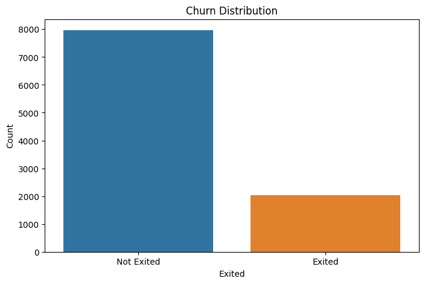

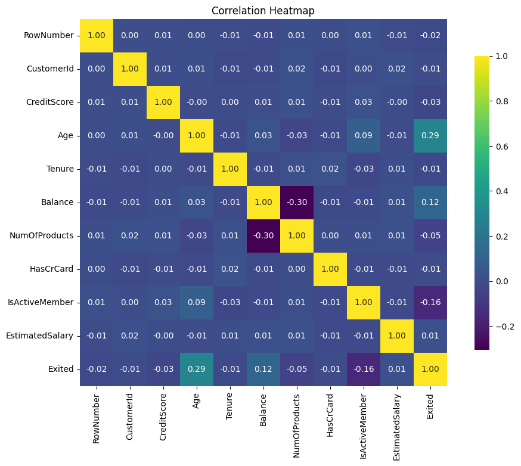

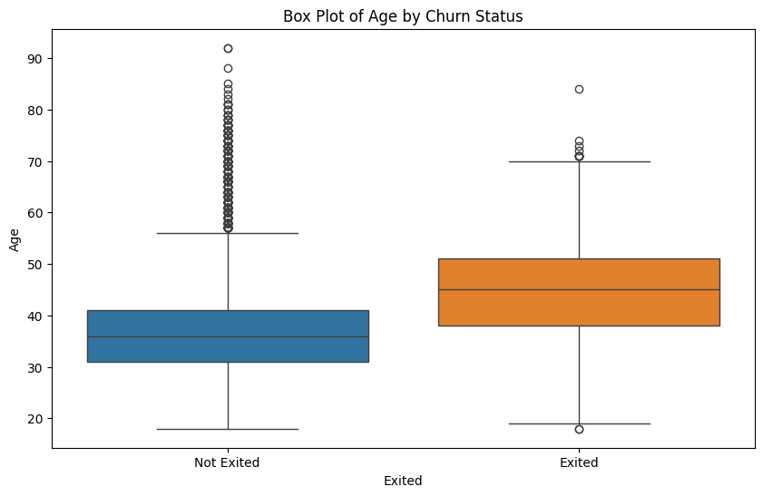

```python
df_info = pd.DataFrame({
    "Column": df.columns,
    "Data Type": df.dtypes,
    "Unique Values": df.nunique(),
    "Missing Values": df.isnull().sum(),
})

print("\nDataFrame Information:")
display(df_info)

duplicate_rows = df.duplicated().sum()
print("\nDuplicate Rows:", duplicate_rows)

numeric_df = df.select_dtypes(include=[np.number])
basic_stats = numeric_df.describe().T
print("\nBasic Statistics for Numeric Columns:")
display(basic_stats)

churn_counts = df['Exited'].value_counts()
churn_distribution = pd.DataFrame({
    'Exited': churn_counts.index,
    'Count': churn_counts.values,
    'Proportion': churn_counts.values / churn_counts.sum()
})
print("\nChurn Distribution:")
display(churn_distribution)

plt.figure(figsize=(8, 5))
sns.barplot(x='Exited', y='Count', data=churn_distribution, palette=['#1f77b4', '#ff7f0e'])
plt.title("Churn Distribution")
plt.xlabel("Exited")
plt.ylabel("Count")
plt.xticks(ticks=[0, 1], labels=['Not Exited', 'Exited'])
plt.show()

plt.figure(figsize=(12, 8))
correlation_matrix = numeric_df.corr()
sns.heatmap(correlation_matrix, annot=True, fmt=".2f", cmap='viridis', square=True, cbar_kws={"shrink": .8})
plt.title("Correlation Heatmap")
plt.show()

plt.figure(figsize=(10, 6))
sns.boxplot(x='Exited', y='Age', data=df, palette=['#1f77b4', '#ff7f0e'])
plt.title("Box Plot of Age by Churn Status")
plt.xlabel("Exited")
plt.ylabel("Age")
plt.xticks(ticks=[0, 1], labels=['Not Exited', 'Exited'])
plt.show()
```

Before I started working on a machine learning algorithm I had to make sure that data are balanced. In order to do that I used a method which was counting the occurrences of each value in the target variable y which is (churn). Based on those results I know if I need to perform some balancing techniques before advancing in the pipeline.

## Data preprocessing

```python
class_counts = y.value_counts()

print("Class Distribution:")
print(class_counts)

class_percentages = y.value_counts(normalize=True) * 100
print("\nClass Percentages:")
print(class_percentages)
```

```
Class Distribution:
Exited
0    7963
1    2037
Name: count, dtype: int64

Class Percentages:
Exited
0    79.63
1    20.37
Name: proportion, dtype: float64
```

After getting data on how balanced the data is, i decided to perform SMOTE Synthetic Minority Over-sampling Technique to balance the data. But to start it i had to remove unneeded columns for balancing so i decided to use simple code drop. Then i had to change all data into numerical, to achieve this i decided to perform one-hot encoding. Then I was able to perform SMOTE which makes sure that the number of clients that churn and don't churn are similar so there is no bias. Then code is counting the number of classes and calculating percentages.

```python
X = df.drop(columns=['Exited', 'RowNumber', 'CustomerId', 'Surname'])

X = pd.get_dummies(X, columns=['Geography', 'Gender'], drop_first=True)

X_balanced, y_balanced = SMOTE(random_state=42).fit_resample(X, y)

class_counts = y_balanced.value_counts()
print("Class Distribution After Balancing:")
print(class_counts)

class_percentages = y_balanced.value_counts(normalize=True) * 100
print("\nClass Percentages After Balancing:")
print(class_percentages)
```

```
Class Distribution After Balancing:
Exited
1    7963
0    7963
Name: count, dtype: int64

Class Percentages After Balancing:
Exited
1    50.0
0    50.0
Name: proportion, dtype: float64
```

```python
label_encoder = LabelEncoder()

for col in df.select_dtypes(include=['object']).columns:
    if df[col].nunique() == 2:
        df[col] = label_encoder.fit_transform(df[col])

df = pd.get_dummies(df, drop_first=True)

scaler = StandardScaler()
X = df.drop('Exited', axis=1)
y = df['Exited']

X_train, X_test, y_train, y_test = train_test_split(X, y, test_size=0.3, random_state=42)

print(f"X_train: {X_train.shape}, y_train: {y_train.shape}")
print(f"X_test: {X_test.shape}, y_test: {y_test.shape}")
```

```
X_train: (7000, 2944), y_train: (7000,)
X_test: (3000, 2944), y_test: (3000,)
```

After splitting the data I can finally start working on machine learning. To select the best model for my business model I decided to test 4 different machine learning algorithms and after getting an accuracy score I will choose the highest which I will use for further training and tuning its hyperparameters. I decided to check 4 models: Linear Regression, Logistic Regression, K-Nearest Neighbors (KNN), and Decision Trees. by using k-fold cross validation. It calculates the average accuracy. Then prints out the results. So to do this firstly I did a model initializing which purpose is to create 4 different machine learning models and corresponding values. Then I created a customer scorer for Linear Regression that outputs continuous values. To convert them into binary outcomes (0 or 1), this function applies a threshold of 0.5. Then i used loop to go over each models dictionary. In last part every model is evaluated using 5-fold cross-validation. The custom scorer is applied only to Linear Regression and other ones are using the default one. Lastly, all results are printed.

## Model Training

```python
models = {
    "Linear Regression": LinearRegression(),
    "Logistic Regression": LogisticRegression(max_iter=200, random_state=42),
    "K-Nearest Neighbors": KNeighborsClassifier(),
    "Decision Trees": DecisionTreeClassifier(random_state=42)
}

def linear_regression_accuracy(y_true, y_pred):
    y_pred_binary = np.where(y_pred >= 0.5, 1, 0)
    return accuracy_score(y_true, y_pred_binary)

custom_scorer = make_scorer(linear_regression_accuracy)

for model_name, model in models.items():
    if model_name == "Linear Regression":
        cv_score = cross_val_score(model, X_train, y_train, cv=5, scoring=custom_scorer)
    else:
        cv_score = cross_val_score(model, X_train, y_train, cv=5, scoring='accuracy')

    print(f"{model_name} - Accuracy: {cv_score.mean():.4f} ± {cv_score.std():.4f}")
```

```
Linear Regression - Accuracy: 0.7589 ± 0.0071
```

```
Logistic Regression - Accuracy: 0.7766 ± 0.0041
K-Nearest Neighbors - Accuracy: 0.7564 ± 0.0047
Decision Trees - Accuracy: 0.8219 ± 0.0034
```

After comparing those 4 models and their accuracy I got results that Decision Trees will be most accurate for my data set so I decided to use it and tune its hyperparameters by performing GridSearch. First I defined the hyperparameter Grid. This implies the hyperparameters that will be tested.

Hyperparameters:

max_depth: Limits the maximum depth of the tree:

3: Max 3 levels.

5: Max 5 levels.

10: Max 10 Levels.

None: No limit tree will keep growing until it cannot be split anymore.

min_samples_split: Minimum number of samples required to split:

2:Node needs 2 samples.

10:Node needs 10 samples.

20: Node needs 20 samples.

min_samples_leaf: Minimum number of samples that a leaf node must have:

1: Leaf node need a minimum of 1 sample.

5: Leaf node need a minimum of 5 samples.

10: Leaf node need a minimum of 10 samples.

After defining hyperparameters I needed to define the model because I decided to use a decision tree i have to define it. After doing that I needed to set up the grid search to find the best hyperparameter combination. GridSearchCV Parameters:

cv=5: 5-fold cross-validation is used.

scoring='accuracy': The metric used to evaluate each model is accuracy.

n_jobs=-1: This is used to tell GridSearchCV to use all CPU available to make sure that program runs faster.

So after doing all that i fitted the decision tree on training data and lastly i printed the best hyperparameters First

```python
param_grid = {
    'max_depth': [3, 5, 10, None],
    'min_samples_split': [2, 10, 20],
    'min_samples_leaf': [1, 5, 10]
}

decision_tree = DecisionTreeClassifier(random_state=42)

best_model = GridSearchCV(
    decision_tree,
    param_grid=param_grid,
    cv=5,
    scoring='accuracy',
    n_jobs=-1
).fit(X_train, y_train)

print("Best Parameters:", best_model.best_params_)
print(f"Test Accuracy: {best_model.score(X_test, y_test):.4f}")
```

```
Best Parameters: {'max_depth': 5, 'min_samples_leaf': 10, 'min_samples_split': 2}
Test Accuracy: 0.8623
```

## Model assessment

So after tuning model hyperparameters I had to test it on an unseen data set to make sure that I can work with different data than it was trained at. To do this I used a DecisionTreeClassifier(max_depth=5, min_samples_leaf=10, min_samples_split=2, random_state=42) and then code fit it to the training data (X_train, y_train). After all training is done the model is used to make predictions on unseen data (X_test). After prediction code is calculating accuracy of these predictions, along with a confusion matrix and a classification report, which provides insights into the model's performance. Lastly, all results are printed.

```python
best_model = DecisionTreeClassifier(max_depth=5, min_samples_leaf=10, min_samples_split=2, random_state=42)

best_model.fit(X_train, y_train)

y_pred = best_model.predict(X_test)

accuracy = accuracy_score(y_test, y_pred)
conf_matrix = confusion_matrix(y_test, y_pred)
class_report = classification_report(y_test, y_pred)

print(f"Model Accuracy on Unseen Test Set: {accuracy:.4f}")
print("\nConfusion Matrix:")
print(conf_matrix)
print("\nClassification Report:")
print(class_report)
```

```
Model Accuracy on Unseen Test Set: 0.8623

Confusion Matrix:
[[2359   57]
 [ 356  228]]

Classification Report:
              precision    recall  f1-score   support

           0       0.87      0.98      0.92      2416
           1       0.80      0.39      0.52       584

    accuracy                           0.86      3000
   macro avg       0.83      0.68      0.72      3000
weighted avg       0.86      0.86      0.84      3000
```

## Conclusion:

The model accuracy on the unseen test set is 0.8623. This means that about 86.23% of the time, the model will correctly predict whether a customer will churn or not. While this accuracy is quite good, it’s essential to consider other aspects of the model’s performance.

[[2359 57]

[ 356 228]]

True Negatives (TN): 2359 (Predicted as 0, actually 0)

False Positives (FP): 57 (Predicted as 1, actually 0)

False Negatives (FN): 356 (Predicted as 0, actually 1)

True Positives (TP): 228 (Predicted as 1, actually 1)

Based on the confusion matrix, the model performs very well at identifying non-churners (TN = 2359), which is reflected in the high precision and recall for class 0 (non-churners). However, the model has difficulty identifying churners, as evidenced by the relatively high number of false negatives (FN = 356).

```
          precision    recall  f1-score   support

       0       0.87      0.98      0.92      2416
       1       0.80      0.39      0.52       584
accuracy                           0.86      3000
macro avg      0.83      0.68      0.72      3000
weighted avg   0.86      0.86      0.84      3000
```

Precision:

Class 0 (Non-churners): 0.87 — Model will predict no churnes 87% of the time correctly.

Class 1 (Churners): 0.80 — Model will predict churners 80% of the time correctly.

Recall:

Class 0 (Non-churners): 0.98 — The model identifies 98% of the actual non-churners correctly.

F1-Score:

Class 0 (Non-churners): 0.92 — This means that there is a good balance between precision and recall for non-churners.

Class 1 (Churners): This means there is poor performance in identifying churners.

Macro Average:

Precision: 0.83

Recall: 0.68 — This shows me that model is much more better on majority class (0) then class (1)

F1-Score: 0.72 — The model's overall performance across both classes.